# Mass-multivariate analysis of 2D contour data in Python

**This notebook**...

- ... provides an overview of mass-multivariate, two-sample hypothesis testing of 2D contour data in Python
- ... explains the details of script `contours_massmv_single.py` which appears in this repository
- ... is limited to mass-multivariate analysis (i.e., multivariate test statistics calculated at each point, with inference conducted in an omnibus sense over all points)
- ... is directed at novice Python users, who may be using Python for the first time.
- ... is likely not useful for intermediate or advanced Python users; please refer isntead to the scripts in `./lmfree2d/Python/`

**Dependencies** (alphabetical order):

- [geomdl](https://github.com/orbingol/NURBS-Python)
- lmfree2d (the `lmfree2d.py` module in this repository)
- [matplotlib](https://matplotlib.org)
- [networkx](https://networkx.github.io)
- [numpy](https://numpy.org)
- pycpd
- [sklearn](https://scikit-learn.org)
- [spm1d](http://www.spm1d.org)

## Install software

Experienced Python user?

The dependency list and links above should be sufficient.

New to Python?

The easiest way to proceed is to:

- Install [Anaconda](https://www.anaconda.com/products/individual). The default Anaconda installation includes:
  - numpy
  - matplotlib
  - networkx
- Open a Command Prompt (Windows), or Terminal (Mac, Linux), and enter the `conda install` commands below to install the remaining packages:
  - geomdl : `conda install -c orbingol geomdl`
  - pycpd : `conda install -c brown-data-science pycpd` (**Linux only**)
  - spm1d : `conda install -c conda-forge spm1d`
- If you are not a Linux user, install pycpd using [pip](https://pypi.org/project/pip/) with the following command: `pip install pycpd`
- Ensure that the `lmfree2d.py` file is on the Python path, as described in this repository's [home page](https://github.com/0todd0000/lmfree2d)
- Launch an interactive Python session (with interactive graphics support) by entering `ipython --pylab` in a Command Prompt (Windows) or Terminal (Mac, Linux). You are now ready to enter the commands below.

# Prepare the workspace

Import all of the packages we'll need for this notebook.

```python
import os
import numpy as np
from matplotlib import pyplot as plt
import lmfree2d as lm
```

## Load landmark data

Let's load the contours CSV file for the Bell dataset, which is located in the `Data` directory of this repository.

```python
dirREPO     = lm.get_repository_path()
name        = 'Bell'
fnameCSV    = os.path.join(dirREPO, 'Data', name, 'contours.csv')
r           = lm.read_csv(fnameCSV)
```

Notes:

- `dirREPO` is the repository's directory (i.e., where the repository is saved on your computer); since `dirREPO` is generally different on different computers, it is referred to generically in this notebook as `./lmfree2d/`
- `name` is the dataset name
- `fnameCSV` is the CSV file name, in this case: `./lmfree2d/Data/Bell/contours.csv`
- `r` is an array containing the contents of the contours CSV file

Let's check the contents of the `r` array.

```python
print( r.shape )
print()
print( r[0].shape )
print( r[5].shape )
print( r[7].shape )
```

```
(10,)

(101, 2)
(120, 2)
(107, 2)
```

Notes:

- `r` contains 10 shapes
- Each element of `r` is a 2D array, representing the contour points for the given shape
- The different shapes generally have a different number of contour points. For example, the first shape (`r[0]`) has 101 points, and the sixth shape (`r[5]`) has 120 points.

Let's plot the contours:

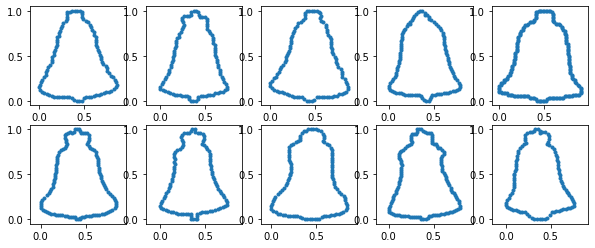

```python
fig,AX = plt.subplots(2, 5, figsize=(10,4))
for ax,rr in zip( AX.flatten(), r):
    ax.plot( rr[:,0], rr[:,1], '.' )
    ax.axis('equal')
plt.show()
```

The shapes can be seen clearly, but the `lmfree2d` module contains various plot functions to more conveniently visualizing the contour shapes. Here is one way:

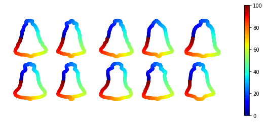

```python
plt.figure(figsize=(10,4))
ax = plt.axes()
lm.plot_point_order(ax, r)
plt.colorbar( ax.collections[0] )
plt.show()
```

Colors in the figure above represent point point order, from the first point (blue) to the last point (red).

Note that the first and last point occur in approximately the same (homologous) location in all 10 shapes.

In general:

- The first point is not necessarily in the same, homologous location across all shapes.
- Points are not necessarily ordered around the shape periphery.

## Shuffle data

To represent general datasets, and also to remove and/or test for bias associated with a particular point ordering, let's shuffle the data points around so that they no longer appear in order, as in the figure above. This can be achieved with the `shuffle` command:

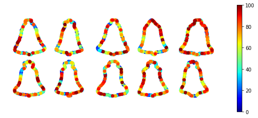

```python
r = lm.shuffle_points(r)


plt.figure(figsize=(10,4))
ax = plt.axes()
lm.plot_point_order(ax, r)
plt.colorbar( ax.collections[0] )
plt.show()
```

Note that the points now appear in a random order.

## Conduct point set registration

Next let's register (i.e., spatially align) the contours. While landmark techniques typically achieve spatial registration using [GPA](https://en.wikipedia.org/wiki/Generalized_Procrustes_analysis), this requires both (a) an identical number of points in all shapes, and (b) that all points are ordered in a homologous manner. As we see in the figures above, the shuffled Bell dataset satisfies neither (a) nor (b).

Let's instead use the [coherent point drift](https://github.com/siavashk/pycpd) (CPD) algorithm to register the shapes. Note that CPD can be regarded as a generalization of GPA to cases (a) and (b). In **lmfree2d**, CPD can be conducted using the `register_cpd` function as follows:

```
185 4
(185, 2)
```

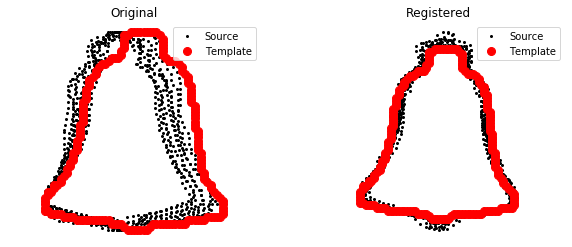

```python
r_template,n,i = lm.get_shape_with_most_points(r) # choose a template shape
r1             = lm.register_cpd(r, r_template)   # register all shapes using the CPD algorithm

print(n, i)
print( r[i].shape )


fig,AX  = plt.subplots(1, 2, figsize=(10,4))
lm.plot_registration(AX[0], r, r_template)
lm.plot_registration(AX[1], r1, r_template)
AX[0].set_title('Original')
AX[1].set_title('Registered')
plt.show()
```

Notes:

- The *template* shape is the shape to which the other shapes (the *sources*) are aligned.
  - The template is fixed (stationary).
  - Sources are transformed (position, rotation and scale) to optimally match the template.
- In this case the shape with the most number of points is selected as the template.
- In general, different templates should be tested to ensure that final results are not affected by the choice of template.
- The variables `n` and `i` represent the number of template points, and the index of the template shape, respectively.
- Following CPD registration, the shapes are clearly better aligned.

## (Re-) Order the contour points

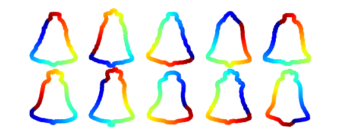

```python
r2 = lm.reorder_points(r1, optimum_order=True, ensure_clockwise=True)


plt.figure(figsize=(10,4))
ax = plt.axes()
lm.plot_point_order(ax, r2)
plt.show()
```

The points are now aligned along the contour. However, due to the shuffling process above, the first point is no longer in a homologous location across shapes.

## Achieve correspondence

Correspondence algorithms aim to match homologous locations across shapes. If all contour points represent homologous locations across all shapes, the shapes are said to be *in correspondence*.

There are many different algorithmic approaches for achieving correspondence. Here a very simple *optimum roll* approach is used. This approach simply rolls the starting point around a *source* contour, until the *source* shape optimally matches a *template* shape. Here '*optimal*' implies that the sum of squared distances between the *source* and *template* points is minimal.

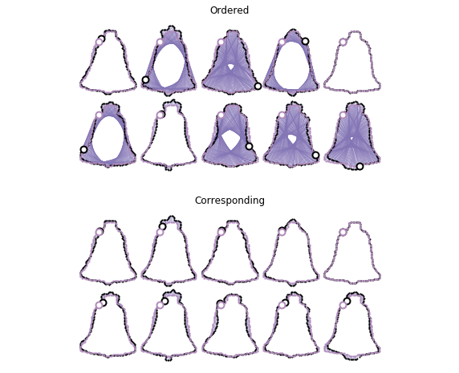

```python
r_template_new = r2[i]                                # get the new template (with ordered points)
r3             = lm.set_npoints(r2, n)                # set a constant number of contour points across all shapes
r4             = lm.corresp_roll(r3, r_template_new)  # run the optimum roll correspondence algorithm



fig,AX  = plt.subplots(2, 1, figsize=(10,8))
lm.plot_correspondence(AX[0], r3, r_template_new)
lm.plot_correspondence(AX[1], r4, r_template_new)
AX[0].set_title('Ordered')
AX[1].set_title('Corresponding')
plt.show()
```

In the figure above, purple lines are correspondence lines, connecting points in the source and template contours. Note that the correspondence algorithm, while simple, has dramatically improved correspondence.

## Conduct hypothesis test

Now that the contour shapes are (i) spatial registered, and (ii) in correspondence, it is possible to conduct mass-multivariate hypothesis testing. Here we use [spm1d](https://spm1d.org) for this purpose. The goal will be to compare the mean shapes from two groups, where the first group consists of the first five shapes and the second group consists of the last five shapes. Briefly, **spm1d** proceeds as follows:

- Calculates the mean location of each contour point for both groups
- Calculates the variance (acutually, covariance) surrounding each mean contour point
- Calculates the test statistic value (the Hotelling's $T^2$ value) at each contour point, which effectively represents the ratio between (i) the mean location difference, and (ii) the location variance.
- Conducts statistical inference (i.e., calculates a p value) across all contour points. This process effectively involves (i) calculating the distribution of $T^2$ values that would be expected by random sampling, given both truly zero difference in mean shapes, and the observed covariance, then (ii) comparing the observed $T^2$ distribution to the one expected by chance.
- More details about these calculations, and why they are statistically valid, are provide in the [spm1d](https://spm1d.org/Documentation.html) and [rft1d](https://spm1d.org/rft1d/) documentation.
- Why "1D" in **spm1d**? Because a contour can be regarded as a 1D continuum spanning locations $u$=0 and $u$=1, where $u$ represents contour location. At each contour location there is a 2D position vector. The location $u$=0.5 represents the location half-way around the contour from the stating location ($u$=0), and the locations $u$=0 and $u$=1 represent the same location.

All of this can be achieved in **lmfree2d** as follows:

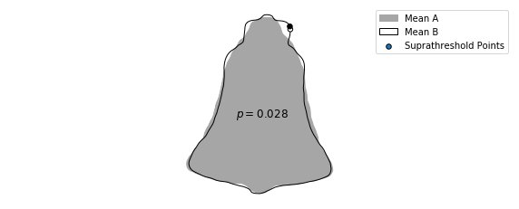

```python
rA      = r4[:5]  # assign the first 5 shapes to one group
rB      = r4[5:]  # assign the last 5 shapes to a second group
results = lm.two_sample_test(rA, rB, parametric=True, alpha=0.05) # conduct a two-sample hypothesis test


plt.figure(figsize=(10,4))
ax = plt.axes()
results.plot(ax)
ax.legend()
plt.show()
```

Notes:

- The mean shapes for each group are plotted
- Dots represent contour points that exceed the critical threshold at $\alpha=0.05$
- The p value represents the probability that random sampling would produce a maximum shape difference as large as the observed shape difference, if the two groups actually has identical means, given the observed shape variance.
- If there are suprathreshold points present, then the p value is at most $\alpha$